# Crypto Derivatives Exchange | Buy, Sell & Trade Cryptocurrency | Bitunix

[figure not shown]

Campaign

Bitunix Tokens  
Distribution

Claim Tokens

Connect Wallet to Win up to 5500 USDT

Or continue with

[video not shown]

[View More](https://support.bitunix.com/hc/en-us/categories/13760946490649)

[figure not shown]

[figure not shown]

[figure not shown]

[figure not shown]

[figure not shown]

[figure not shown]

[figure not shown]

[figure not shown]

[figure not shown]

[figure not shown]

[figure not shown]

[figure not shown]

Trending Cryptocurrencies

View More

Popular Futures

Popular Spot

Gainers

| Trading Pairs | Last Traded Price | 24H Change | 24H High | 24H Trading Volume | Chart |  |
| --- | --- | --- | --- | --- | --- | --- |
| BTCUSDT | ₮62,196.3 $62,196.30 | -0.25% | 63,175.5 | 2.94B |  | Trade |
| ETHUSDT | ₮2,434.98 $2,434.98 | +0.40% | 2,472.77 | 1.29B |  | Trade |
| SOLUSDT | ₮143.0990 $143.09 | +0.10% | 145.4470 | 366.20M |  | Trade |
| SUIUSDT | ₮1.9064 $1.90 | -5.12% | 2.0489 | 277.75M |  | Trade |
| 1000PEPEUSDT | ₮0.0096659 $0.009665 | +0.80% | 0.0098524 | 237.81M |  | Trade |

Who is using Bitunix

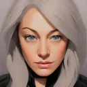

Trade Travel Chill

Crypto Trader and Educator. Learn how to trade crypto, generate profits, protect your gains, change your life and live the Trade Travel Chill lifestyle!

Followers: 37.8k

[figure not shown]

ORACLE FAST MONEY TRADER

"Trading is a war and Bitunix is an epic place for War On The 1 Minute Chart"

Followers: 55k

[figure not shown]

Crash Trading

Hundreds of exchanges I have used, Bitunix is one of the last real exchanges left in the game.

Followers: 51.8K

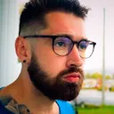

Invest & Trade With Jaxx

I appreciate how Bitunix has managed to strike the perfect balance between advanced features and user-friendliness.

Followers: 49.3K

[figure not shown]

1336 Crypto Club

Bitunix's friendly customer service brings a friendly environment for cryptocurrencies and the platform provides traders with a good trading depth and liquidity and a friendly experience for novice and professional traders.

Followers: 3.3K

[figure not shown]

Tiger Crypto

Bitunix is very suitable for "futures traders". The depth of futures market is deep enough, the slippage is minimized among all exchanges, the operation is smooth and fluent, and has a U.S. and Canadian license, which is highly recommended by me Tiger.

Followers: 4.3k

[figure not shown]

Crypto_Kai

Choose Bitunix exchange to enjoy low trading fees, efficient security systems, intuitive user interface and excellent customer service. Providing users with a wide range of assets, fast trade execution and solid security measures, Bitunix is the first choice for traders seeking efficiency!

Followers: 1.1k

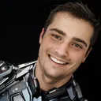

investwithrex

Every trade is a lesson, every loss a tuition

Followers: 67.9K

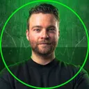

AltCryptoGems

The exchange with one of the smoothest user interfaces, spot on marketing and having the ideal balance for professional traders as well as new, enthusiastic, crypto traders.

Followers: 314K

[figure not shown]

TrippaTrading

I like the fact that Bitunix is completely focused on trading and can therefore provide a good trading experience for anyone who wants to trade in a professional environment.

Followers: 17.1k

[figure not shown]

Heyman

Bitunix has a user-friendly interface, is available in different languages, and supports a wide range of tokens while keeping listing new tokens. It also has an excellent trading depth, with fewer sudden extreme price changes, making it more user-friendly.

Followers: 2.2K

USDT

BTC

BNB

SHIB

SAND

FTM

DAI

APE

CRO

GMT

DYDX

1INCH

SRM

JST

MKR

REEF

HOT

REN

INJ

LOOM

WOO

AMP

MBOX

RLC

CELR

GFT

CFX

HIGH

ARB

RDNT

WLD

CYBER

EURT

CTSI

MAV

JUP

SATS

ALICE

BEAM

CULO

ONDO

W

OMNI

FLUX

PNG

FYN

RIO

BUBBLE

VANRY

CPOOL

VRA

GME

KEY

FTT

MYRIA

G

FIGHT

USDE

L3

MEMETOON

SYN

SUN

DATA

POL

BURGER

CAT

HMSTR

FIDA

BTC

BNB

SHIB

SAND

FTM

DAI

APE

CRO

GMT

DYDX

1INCH

SRM

JST

MKR

REEF

HOT

REN

INJ

LOOM

WOO

AMP

MBOX

RLC

CELR

GFT

CFX

HIGH

ARB

RDNT

WLD

CYBER

EURT

CTSI

MAV

JUP

SATS

ALICE

BEAM

CULO

ONDO

W

OMNI

FLUX

PNG

FYN

RIO

BUBBLE

VANRY

CPOOL

VRA

GME

KEY

FTT

MYRIA

G

FIGHT

USDE

L3

MEMETOON

SYN

SUN

DATA

POL

BURGER

CAT

HMSTR

FIDA

ETH

LTC

SNT

FIL

ENJ

CRV

MASK

ATOM

BAL

AAVE

SOL

KNC

SPELL

EGLD

BTT

ANKR

GRT

IMX

NEAR

DENT

VGX

JASMY

RSR

GAL

API3

BLUR

SSV

GLM

JOE

PEPE

OP

TRB

ORDI

BONK

AI

MAGIC

PIXEL

FLOKI

NFP

BRETT

PUMP

ENA

OM

REZ

TLM

AGI

VTHO

NOS

BICO

PENG

DEGEN

IO

PIZZA

BADGER

LISTA

MOG

BANANA

NAKA

TRUMP

AGLA

VOXEL

SUNDOG

CREAM

VIDT

UXLINK

CATI

GINNAN

EIGEN

LTC

SNT

FIL

ENJ

CRV

MASK

ATOM

BAL

AAVE

SOL

KNC

SPELL

EGLD

BTT

ANKR

GRT

IMX

NEAR

DENT

VGX

JASMY

RSR

GAL

API3

BLUR

SSV

GLM

JOE

PEPE

OP

TRB

ORDI

BONK

AI

MAGIC

PIXEL

FLOKI

NFP

BRETT

PUMP

ENA

OM

REZ

TLM

AGI

VTHO

NOS

BICO

PENG

DEGEN

IO

PIZZA

BADGER

LISTA

MOG

BANANA

NAKA

TRUMP

AGLA

VOXEL

SUNDOG

CREAM

VIDT

UXLINK

CATI

GINNAN

EIGEN

TRX

LINK

XRP

DOGE

AXS

PEOPLE

NMR

AVAX

SUSHI

FLOW

ZEC

BAND

WIN

BAT

NFT

CEEK

ONT

FXS

CAKE

PYR

LPT

FET

LOOKS

YGG

PHA

DAR

LQTY

DODO

GHST

MATIC

SUI

BIGTIME

EDU

MEME

ALT

PYTH

C98

PERP

PORTAL

WIF

GAU

AEVO

BVM

AIOZ

MEW

HNT

MERL

NOT

CEL

POPCAT

COMBO

STG

ATH

ZK

NRN

RENDER

WAXP

PONKE

WSOL

AIT

TOMI

ALPACA

DOGS

OOKI

ZBU

TERMINUS

CWIF

NEIRO1

LINK

XRP

DOGE

AXS

PEOPLE

NMR

AVAX

SUSHI

FLOW

ZEC

BAND

WIN

BAT

NFT

CEEK

ONT

FXS

CAKE

PYR

LPT

FET

LOOKS

YGG

PHA

DAR

LQTY

DODO

GHST

MATIC

SUI

BIGTIME

EDU

MEME

ALT

PYTH

C98

PERP

PORTAL

WIF

GAU

AEVO

BVM

AIOZ

MEW

HNT

MERL

NOT

CEL

POPCAT

COMBO

STG

ATH

ZK

NRN

RENDER

WAXP

PONKE

WSOL

AIT

TOMI

ALPACA

DOGS

OOKI

ZBU

TERMINUS

CWIF

NEIRO1

YFI

UNI

ADA

MANA

DOT

USDC

CHZ

WBTC

SNX

QNT

SLP

IQ

ENS

COMP

HFT

XTZ

OKB

NEXO

LUNC

STORJ

CVX

HOOK

HEX

BSW

COTI

LDO

AUDIO

ID

CHESS

VET

OZON

XAUT

OGN

XAI

JTO

PENDLE

HIFI

TOKEN

SWCH

BOME

ETHFI

TON

ACH

PRIME

ZEUS

MAVIA

RARE

GUMMY

SILLY

SLERF

TRU

ILV

MAGA

ZRO

DOP

MPL

OXT

NEIRO

MAX

CXT

ZKJ

LOKA

SLF

NPC

VISTA

NEIROETH

SIDUS

UNI

ADA

MANA

DOT

USDC

CHZ

WBTC

SNX

QNT

SLP

IQ

ENS

COMP

HFT

XTZ

OKB

NEXO

LUNC

STORJ

CVX

HOOK

HEX

BSW

COTI

LDO

AUDIO

ID

CHESS

VET

OZON

XAUT

OGN

XAI

JTO

PENDLE

HIFI

TOKEN

SWCH

BOME

ETHFI

TON

ACH

PRIME

ZEUS

MAVIA

RARE

GUMMY

SILLY

SLERF

TRU

ILV

MAGA

ZRO

DOP

MPL

OXT

NEIRO

MAX

CXT

ZKJ

LOKA

SLF

NPC

VISTA

NEIROETH

SIDUS

Why Bitunix?

Secure

We offer industry-leading secure cryptocurrency trading platform, maintaining a robust reserve fund that exceeds 1:1 ratio against user holdings.

Seamless

Enjoy the benefits of efficient and real-time online trading. Start your crypto journey with just $10 investment.

Insights

Get real-time updates and sharp insights about the cryptocurrency market.

Service

Experience unparalleled assistance with multilingual 24/7 customer support. Ensuring a seamless and satisfying trading experience.

Begin Your Cryptocurrency Journey Effortlessly

[figure not shown]

Create your Bitunix account

Deposit funds

Start trading

Reviews of Bitunix from Worldwide Media

[figure not shown]

Bitunix Records All-Time Highest Trading Volume In October

Details

[figure not shown]

Bitunix Exchange Now Supports Visa and Mastercard Payments

Details

[figure not shown]

Slater Says "Bitunix Prioritizes Compliance and User Education"

Details

[figure not shown]

Bitunix at Blockchain Economy Summit Dubai 2023: Highlights of First Exhibit

Details

[figure not shown]

Unveiling the Best No KYC Exchanges of 2024

Details

[figure not shown]

Bitunix expands to LATAM and offers trading of 180 cryptocurrencies without KYC

Details

[figure not shown]

Bitunix and MoonPay Join Forces for Seamless Crypto Trading

Details

Your Crypto Exchange, Anytime, Anywhere:

Start Trading Today!

[App Store](https://apps.apple.com/app/id6446243957?platform=iphone)

[Google Play](https://play.google.com/store/apps/details?id=io.bitunix.android) [Android APK](https://download.bitunix.com/bitunix.apk)

[figure not shown]

**About**

**Laws**

**Services**

**Support**

**Partners**

[Referral](https://www.bitunix.com/referral)

© 2022 - 2024 Bitunix.com. All rights reserved

Register now and receive up to $5,500 worth of exclusive gifts for newcomers!

[interactive chart not shown]